# The B73 checks at the production run’s sites

Read counts of the 23 B73 checks at the variant-calling production run’s union sites (run 1367152, chr1-chr10; 2026-10-17)

Author

Fausto Rodríguez-Zapata

Published

October 17, 2026

## Why

CRISP is meant to run on three kinds of pool per donor: its BC1 pools, the in silico pool of its NILs, and a pool of the B73 checks that are not contaminated (user, 2026-10-17). A donor’s own pools share almost all its variants, so the B73 checks give CRISP its contrast. This notebook asks which B73 checks are clean, using only the production run’s calls: every union site of run 1367152 (chr1-chr10), and each check’s reads there.

- **ALT reads**: reads carrying the run’s ALT allele at a site; **other reads**: a third allele; **ALT share** = ALT reads / all reads at the run’s sites.
- The checks: the 12 batch-1 B73-bulk checks (the pipeline’s check filter tests these) and the 11 batch-2 B73 checks (in the run’s sheet, never tested or used).
- Reads are counted as the run counts the BC1 pools at the union: MAPQ and base quality >= 20, no duplicate, secondary or supplementary records.

## Read counts

Each check over chr1-chr10: run sites with >= 1 read, reads, REF, ALT and other reads.

| check | batch | sites | reads | ref | alt | other | ALT share (%) |
| --- | --- | --- | --- | --- | --- | --- | --- |
| PN5_SID468 | batch 1, B73-bulk | 3,315,178 | 4,479,161 | 4,395,616 | 79,673 | 3,872 | 1.779 |
| PN3_SID236 | batch 1, B73-bulk | 4,454,739 | 6,417,442 | 6,303,251 | 108,570 | 5,621 | 1.692 |
| PN10_SID893 | batch 1, B73-bulk | 5,817,392 | 10,709,387 | 10,664,549 | 38,740 | 6,098 | 0.362 |
| PN5_SID429 | batch 1, B73-bulk | 4,327,589 | 6,491,386 | 6,467,644 | 20,034 | 3,708 | 0.309 |
| PN9_SID838 | batch 1, B73-bulk | 3,671,378 | 5,054,563 | 5,037,422 | 14,601 | 2,540 | 0.289 |
| PN3_SID255 | batch 1, B73-bulk | 4,904,517 | 7,774,119 | 7,754,502 | 15,152 | 4,465 | 0.195 |
| PN3_SID203 | batch 1, B73-bulk | 4,443,473 | 6,631,910 | 6,616,410 | 11,654 | 3,846 | 0.176 |
| PN5_SID442 | batch 1, B73-bulk | 4,421,872 | 6,620,678 | 6,606,805 | 10,153 | 3,720 | 0.153 |
| PN4_SID326 | batch 1, B73-bulk | 5,115,831 | 8,584,514 | 8,567,666 | 12,264 | 4,584 | 0.143 |
| PN8_SID693 | batch 1, B73-bulk | 5,527,524 | 9,992,505 | 9,973,909 | 13,635 | 4,961 | 0.136 |
| PN6_SID576 | batch 1, B73-bulk | 3,811,986 | 5,396,772 | 5,386,457 | 7,342 | 2,973 | 0.136 |
| P4376 | batch 2, B73 | 6,023,401 | 8,811,292 | 8,798,915 | 11,591 | 786 | 0.132 |
| PN8_SID751 | batch 1, B73-bulk | 4,648,324 | 7,129,123 | 7,116,633 | 9,106 | 3,384 | 0.128 |
| P4091 | batch 2, B73 | 3,435,916 | 4,141,548 | 4,136,821 | 4,376 | 351 | 0.106 |
| P4051 | batch 2, B73 | 3,352,183 | 4,029,687 | 4,025,125 | 4,252 | 310 | 0.106 |
| P4024 | batch 2, B73 | 5,932,250 | 8,612,812 | 8,603,174 | 8,909 | 729 | 0.103 |
| P4251 | batch 2, B73 | 5,005,847 | 6,730,808 | 6,723,207 | 6,944 | 657 | 0.103 |
| P4187 | batch 2, B73 | 3,164,070 | 3,760,660 | 3,756,514 | 3,783 | 363 | 0.101 |
| P4119 | batch 2, B73 | 7,319,226 | 12,379,716 | 12,366,254 | 12,386 | 1,076 | 0.100 |
| P4092 | batch 2, B73 | 5,207,903 | 7,116,270 | 7,108,576 | 7,088 | 606 | 0.100 |
| P4180 | batch 2, B73 | 2,553,483 | 2,924,456 | 2,921,380 | 2,844 | 232 | 0.097 |
| P4013 | batch 2, B73 | 6,106,482 | 9,003,902 | 8,994,498 | 8,713 | 691 | 0.097 |
| P4107 | batch 2, B73 | 4,162,925 | 5,301,025 | 5,295,438 | 5,115 | 472 | 0.096 |

ALT share (%) per chromosome.

| sample | chr1 | chr2 | chr3 | chr4 | chr5 | chr6 | chr7 | chr8 | chr9 | chr10 |
| --- | --- | --- | --- | --- | --- | --- | --- | --- | --- | --- |
| PN5_SID468 | 0.961 | 0.331 | 6.093 | 0.371 | 3.027 | 6.897 | 0.285 | 0.429 | 0.303 | 0.275 |
| PN3_SID236 | 2.448 | 2.063 | 1.171 | 1.361 | 1.719 | 1.186 | 0.577 | 2.425 | 1.972 | 1.629 |
| PN10_SID893 | 0.432 | 0.406 | 0.310 | 0.435 | 0.682 | 0.317 | 0.129 | 0.289 | 0.187 | 0.292 |
| PN5_SID429 | 0.468 | 0.363 | 0.154 | 0.248 | 0.587 | 0.220 | 0.186 | 0.139 | 0.123 | 0.521 |
| PN9_SID838 | 0.504 | 0.176 | 0.325 | 0.415 | 0.411 | 0.132 | 0.170 | 0.281 | 0.109 | 0.160 |
| PN3_SID255 | 0.315 | 0.119 | 0.124 | 0.220 | 0.435 | 0.122 | 0.192 | 0.114 | 0.109 | 0.120 |
| PN3_SID203 | 0.315 | 0.145 | 0.231 | 0.075 | 0.315 | 0.085 | 0.094 | 0.162 | 0.124 | 0.087 |
| PN5_SID442 | 0.295 | 0.139 | 0.091 | 0.106 | 0.344 | 0.114 | 0.076 | 0.078 | 0.110 | 0.082 |
| PN4_SID326 | 0.278 | 0.129 | 0.097 | 0.086 | 0.308 | 0.099 | 0.072 | 0.072 | 0.103 | 0.096 |
| PN8_SID693 | 0.255 | 0.111 | 0.066 | 0.089 | 0.337 | 0.119 | 0.083 | 0.073 | 0.082 | 0.086 |
| PN6_SID576 | 0.252 | 0.105 | 0.093 | 0.079 | 0.349 | 0.114 | 0.080 | 0.075 | 0.071 | 0.075 |
| P4376 | 0.285 | 0.080 | 0.059 | 0.067 | 0.443 | 0.091 | 0.057 | 0.041 | 0.050 | 0.061 |
| PN8_SID751 | 0.250 | 0.091 | 0.095 | 0.090 | 0.325 | 0.100 | 0.060 | 0.058 | 0.056 | 0.065 |
| P4091 | 0.269 | 0.073 | 0.031 | 0.049 | 0.401 | 0.033 | 0.027 | 0.017 | 0.023 | 0.019 |
| P4051 | 0.262 | 0.064 | 0.029 | 0.039 | 0.416 | 0.051 | 0.035 | 0.021 | 0.016 | 0.022 |
| P4024 | 0.283 | 0.060 | 0.030 | 0.045 | 0.375 | 0.043 | 0.027 | 0.021 | 0.018 | 0.022 |
| P4251 | 0.260 | 0.057 | 0.029 | 0.042 | 0.401 | 0.045 | 0.035 | 0.019 | 0.022 | 0.026 |
| P4187 | 0.258 | 0.051 | 0.025 | 0.037 | 0.411 | 0.040 | 0.029 | 0.018 | 0.020 | 0.023 |
| P4119 | 0.260 | 0.059 | 0.033 | 0.041 | 0.379 | 0.039 | 0.026 | 0.018 | 0.023 | 0.020 |
| P4092 | 0.262 | 0.053 | 0.027 | 0.038 | 0.381 | 0.050 | 0.026 | 0.023 | 0.019 | 0.024 |
| P4180 | 0.250 | 0.051 | 0.026 | 0.048 | 0.364 | 0.035 | 0.037 | 0.020 | 0.021 | 0.025 |
| P4013 | 0.271 | 0.057 | 0.026 | 0.043 | 0.341 | 0.041 | 0.021 | 0.017 | 0.029 | 0.022 |
| P4107 | 0.248 | 0.050 | 0.026 | 0.042 | 0.363 | 0.038 | 0.031 | 0.028 | 0.024 | 0.022 |

## The two batches

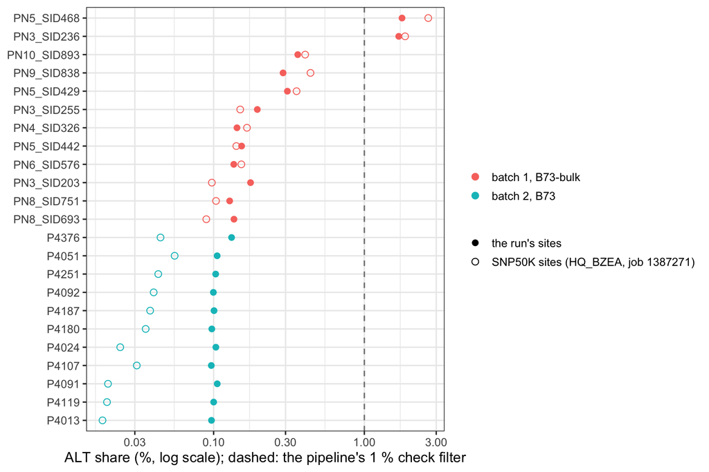

## Mismatches over the whole genome

`samtools stats` of each check’s CRAM (alignment QC): mismatches over all mapped bases, no site list. In B73 nearly every mismatch is a sequencing error, so this ranks the checks by sequencing quality; contamination adds little to it (5 % teosinte reads, which differ from B73 at ~1 % of their bases, add ~0.05 %).

Whole-genome mismatch rate against the two site-based ALT shares.

| check | batch | bases mapped | mismatches | mismatch rate (%) | ALT share, run’s sites (%) | ALT share, SNP50K sites (%) |
| --- | --- | --- | --- | --- | --- | --- |
| PN3_SID236 | batch 1, B73-bulk | 1181207466 | 8,752,819 | 0.741 | 1.692 | 1.864 |
| PN5_SID468 | batch 1, B73-bulk | 814077422 | 5,362,579 | 0.659 | 1.779 | 2.656 |
| PN3_SID203 | batch 1, B73-bulk | 1156902571 | 7,054,078 | 0.610 | 0.176 | 0.097 |
| PN3_SID255 | batch 1, B73-bulk | 1353467741 | 8,142,018 | 0.602 | 0.195 | 0.150 |
| PN5_SID442 | batch 1, B73-bulk | 1203294869 | 6,894,392 | 0.573 | 0.153 | 0.141 |
| PN4_SID326 | batch 1, B73-bulk | 1548612407 | 8,470,294 | 0.547 | 0.143 | 0.166 |
| PN5_SID429 | batch 1, B73-bulk | 1226219239 | 6,613,679 | 0.539 | 0.309 | 0.355 |
| PN10_SID893 | batch 1, B73-bulk | 1928385463 | 10,311,964 | 0.535 | 0.362 | 0.405 |
| PN8_SID693 | batch 1, B73-bulk | 1781442988 | 8,862,202 | 0.497 | 0.136 | 0.089 |
| PN8_SID751 | batch 1, B73-bulk | 1316724272 | 6,395,520 | 0.486 | 0.128 | 0.104 |
| PN9_SID838 | batch 1, B73-bulk | 883679781 | 4,236,393 | 0.479 | 0.289 | 0.439 |
| PN6_SID576 | batch 1, B73-bulk | 1016721886 | 4,872,704 | 0.479 | 0.136 | 0.153 |
| P4251 | batch 2, B73 | 2114895021 | 2,967,578 | 0.140 | 0.103 | 0.043 |
| P4187 | batch 2, B73 | 1182858265 | 1,555,618 | 0.132 | 0.101 | 0.038 |
| P4119 | batch 2, B73 | 3882680978 | 4,650,896 | 0.120 | 0.100 | 0.020 |
| P4091 | batch 2, B73 | 1359383626 | 1,587,858 | 0.117 | 0.106 | 0.020 |
| P4092 | batch 2, B73 | 2348999281 | 2,662,044 | 0.113 | 0.100 | 0.040 |
| P4024 | batch 2, B73 | 2913845696 | 3,134,808 | 0.108 | 0.103 | 0.024 |
| P4051 | batch 2, B73 | 1320117217 | 1,415,432 | 0.107 | 0.106 | 0.055 |
| P4107 | batch 2, B73 | 1650367536 | 1,728,739 | 0.105 | 0.096 | 0.031 |
| P4180 | batch 2, B73 | 907712007 | 919,943 | 0.101 | 0.097 | 0.035 |
| P4013 | batch 2, B73 | 2996325732 | 2,854,014 | 0.095 | 0.097 | 0.018 |
| P4376 | batch 2, B73 | 2930836695 | 2,677,394 | 0.091 | 0.132 | 0.044 |

The base qualities (`samtools stats` of the same CRAMs) show why: batch 1 is sequenced worse.

Base quality and mismatch rate per check.

| check | batch | average base quality | bases < Q20 (%) | bases < Q30 (%) | mismatch rate (%) |
| --- | --- | --- | --- | --- | --- |
| PN3_SID236 | batch 1, B73-bulk | 34.8 | 5.30 | 12.04 | 0.741 |
| PN5_SID468 | batch 1, B73-bulk | 35.0 | 4.71 | 10.84 | 0.659 |
| PN3_SID203 | batch 1, B73-bulk | 34.8 | 5.26 | 11.92 | 0.610 |
| PN3_SID255 | batch 1, B73-bulk | 34.9 | 5.20 | 11.84 | 0.602 |
| PN5_SID442 | batch 1, B73-bulk | 34.9 | 5.09 | 11.47 | 0.573 |
| PN4_SID326 | batch 1, B73-bulk | 35.0 | 4.94 | 11.17 | 0.547 |
| PN5_SID429 | batch 1, B73-bulk | 35.1 | 4.65 | 10.76 | 0.539 |
| PN10_SID893 | batch 1, B73-bulk | 35.1 | 4.48 | 10.68 | 0.535 |
| PN8_SID693 | batch 1, B73-bulk | 35.1 | 4.53 | 10.50 | 0.497 |
| PN8_SID751 | batch 1, B73-bulk | 35.1 | 4.47 | 10.42 | 0.486 |
| PN9_SID838 | batch 1, B73-bulk | 35.2 | 4.18 | 9.97 | 0.479 |
| PN6_SID576 | batch 1, B73-bulk | 35.2 | 4.35 | 10.15 | 0.479 |
| P4251 | batch 2, B73 | 39.8 | 1.49 | 5.46 | 0.140 |
| P4187 | batch 2, B73 | 40.0 | 1.18 | 4.59 | 0.132 |
| P4119 | batch 2, B73 | 40.1 | 1.13 | 4.23 | 0.120 |
| P4091 | batch 2, B73 | 40.0 | 1.40 | 4.93 | 0.117 |
| P4092 | batch 2, B73 | 40.0 | 1.32 | 4.71 | 0.113 |
| P4024 | batch 2, B73 | 39.9 | 1.61 | 5.27 | 0.108 |
| P4051 | batch 2, B73 | 40.0 | 1.38 | 4.64 | 0.107 |
| P4107 | batch 2, B73 | 40.2 | 0.98 | 3.72 | 0.105 |
| P4180 | batch 2, B73 | 40.1 | 1.12 | 4.04 | 0.101 |
| P4013 | batch 2, B73 | 39.9 | 1.58 | 4.85 | 0.095 |
| P4376 | batch 2, B73 | 40.1 | 1.16 | 3.98 | 0.091 |

### Mismatches on high-quality bases

Mismatch rate on bases of quality >= 30, per check.

| check | batch | bases at Q>=30 | mismatches at Q>=30 | mismatch rate at Q>=30 (%) | mismatch rate, all bases (%) | ALT share, run’s sites (%) |
| --- | --- | --- | --- | --- | --- | --- |
| PN5_SID468 | batch 1, B73-bulk | 718896869 | 1,255,562 | 0.1747 | 0.659 | 1.779 |
| PN3_SID236 | batch 1, B73-bulk | 1024238204 | 1,725,093 | 0.1684 | 0.741 | 1.692 |
| PN10_SID893 | batch 1, B73-bulk | 1694403602 | 1,613,083 | 0.0952 | 0.535 | 0.362 |
| PN5_SID429 | batch 1, B73-bulk | 1080783112 | 931,253 | 0.0862 | 0.539 | 0.309 |
| PN9_SID838 | batch 1, B73-bulk | 787806579 | 630,440 | 0.0800 | 0.479 | 0.289 |
| PN6_SID576 | batch 1, B73-bulk | 902167860 | 688,344 | 0.0763 | 0.479 | 0.136 |
| PN3_SID255 | batch 1, B73-bulk | 1175039538 | 869,970 | 0.0740 | 0.602 | 0.195 |
| PN5_SID442 | batch 1, B73-bulk | 1053935029 | 779,630 | 0.0740 | 0.573 | 0.153 |
| PN3_SID203 | batch 1, B73-bulk | 1002569976 | 711,859 | 0.0710 | 0.610 | 0.176 |
| PN4_SID326 | batch 1, B73-bulk | 1354701713 | 945,524 | 0.0698 | 0.547 | 0.143 |
| PN8_SID693 | batch 1, B73-bulk | 1572389469 | 1,085,897 | 0.0691 | 0.497 | 0.136 |
| PN8_SID751 | batch 1, B73-bulk | 1164537655 | 768,127 | 0.0660 | 0.486 | 0.128 |
| P4107 | batch 2, B73 | 1529293442 | 383,631 | 0.0251 | 0.105 | 0.096 |
| P4187 | batch 2, B73 | 1101604017 | 273,684 | 0.0248 | 0.132 | 0.101 |
| P4180 | batch 2, B73 | 856687794 | 208,556 | 0.0243 | 0.101 | 0.097 |
| P4119 | batch 2, B73 | 3611724520 | 873,574 | 0.0242 | 0.120 | 0.100 |
| P4051 | batch 2, B73 | 1290811919 | 287,466 | 0.0223 | 0.107 | 0.106 |
| P4376 | batch 2, B73 | 2883559435 | 630,016 | 0.0218 | 0.091 | 0.132 |
| P4091 | batch 2, B73 | 1327973503 | 288,575 | 0.0217 | 0.117 | 0.106 |
| P4251 | batch 2, B73 | 1995552114 | 432,840 | 0.0217 | 0.140 | 0.103 |
| P4092 | batch 2, B73 | 2275897757 | 488,696 | 0.0215 | 0.113 | 0.100 |
| P4013 | batch 2, B73 | 2933687159 | 615,910 | 0.0210 | 0.095 | 0.097 |
| P4024 | batch 2, B73 | 2979292253 | 579,820 | 0.0195 | 0.108 | 0.103 |

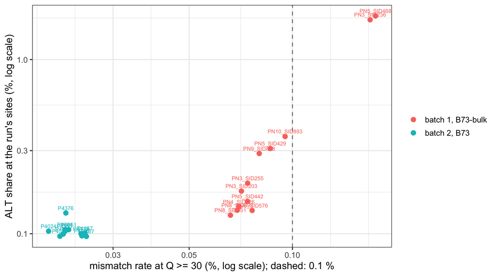

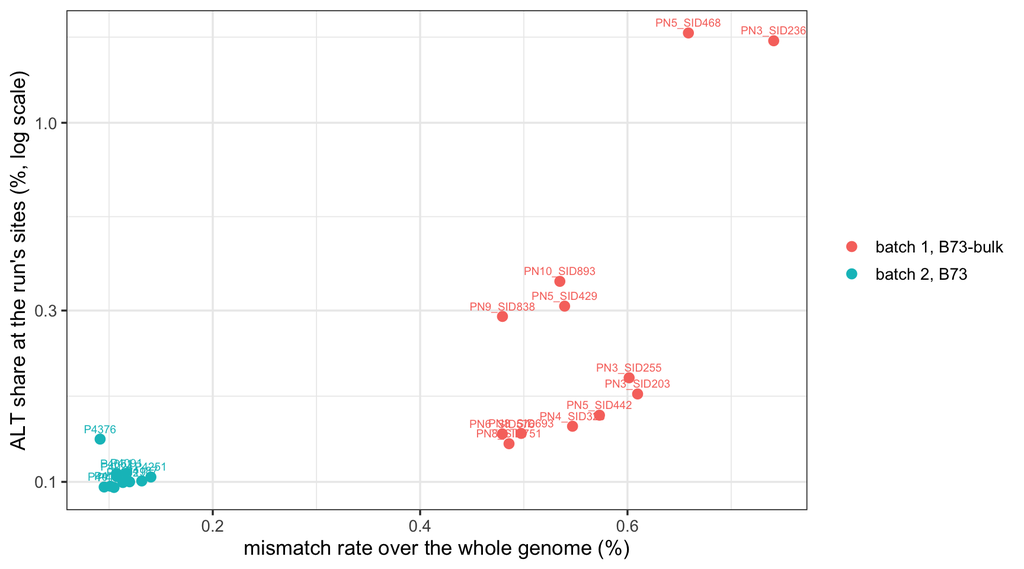

## Along the genome

Each row is a check, each tile 1 Mb; colour is the ALT share of its reads at the run’s sites. A block of high share on one chromosome is donor DNA in that region (a mislabel or an introgressed segment); an even haze over the genome is leakage or error.

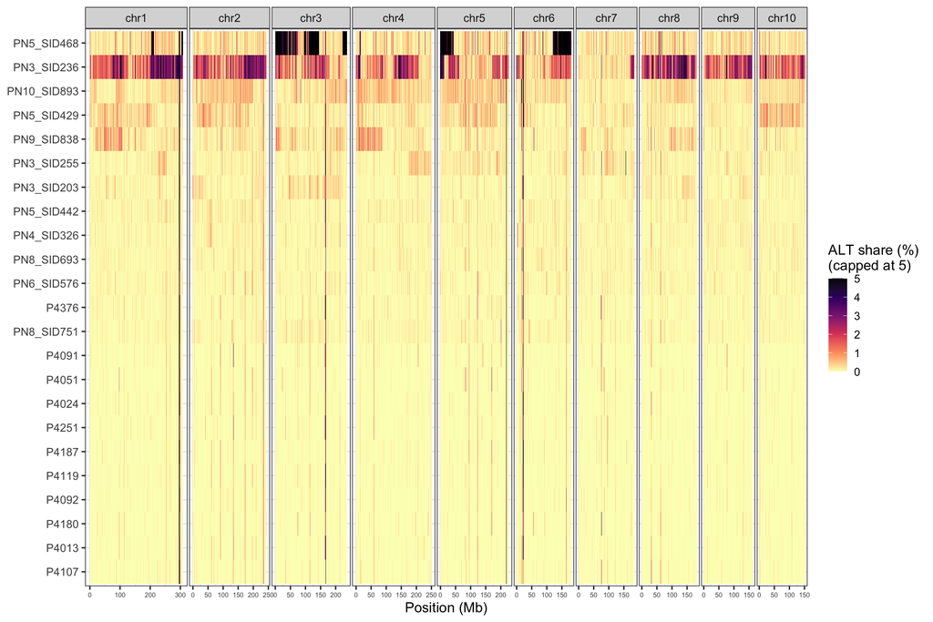

## Whose alleles

For each site where a check has ALT reads: how many of the run’s donors carry that ALT in their donor alleles. An ALT from cross-talk or contamination matches the donors of the sample it came from; a sequencing error matches whatever donors share the site by chance.

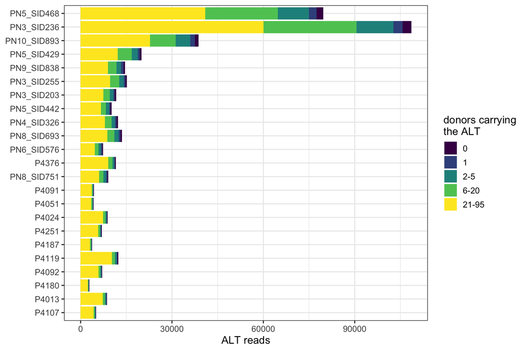

ALT reads at sites where a single donor carries the ALT, by that donor’s taxon.

| sample | diploperennis | huehuetenangensis | luxurians | mexicana | parviglumis |
| --- | --- | --- | --- | --- | --- |
| P4013 | 24 | 8 | 16 | 31 | 66 |
| P4024 | 20 | 15 | 17 | 33 | 70 |
| P4051 | 11 | 6 | 6 | 18 | 28 |
| P4091 | 10 | 5 | 8 | 24 | 44 |
| P4092 | 18 | 6 | 13 | 35 | 53 |
| P4107 | 16 | 2 | 7 | 19 | 44 |
| P4119 | 37 | 22 | 20 | 62 | 85 |
| P4180 | 6 | 2 | 4 | 16 | 28 |
| P4187 | 12 | 6 | 5 | 17 | 43 |
| P4251 | 16 | 11 | 9 | 44 | 57 |
| P4376 | 27 | 13 | 22 | 82 | 76 |
| PN10_SID893 | 160 | 82 | 462 | 270 | 541 |
| PN3_SID203 | 68 | 39 | 35 | 200 | 140 |
| PN3_SID236 | 200 | 149 | 156 | 1250 | 1323 |
| PN3_SID255 | 72 | 46 | 62 | 191 | 165 |
| PN4_SID326 | 67 | 56 | 38 | 158 | 157 |
| PN5_SID429 | 71 | 41 | 44 | 291 | 187 |
| PN5_SID442 | 61 | 33 | 34 | 133 | 147 |
| PN5_SID468 | 175 | 85 | 126 | 999 | 1114 |
| PN6_SID576 | 73 | 34 | 30 | 81 | 106 |
| PN8_SID693 | 87 | 63 | 64 | 187 | 214 |
| PN8_SID751 | 62 | 32 | 32 | 90 | 112 |
| PN9_SID838 | 44 | 448 | 55 | 104 | 165 |